# Probability of Recession

A Simple Model for Forecasting

Hamid Shafiezadeh

2023-07-02

> *“… the first law of financial crises: an unsustainable position can continue for far longer that you would believe possible…the second law of financial crises: when an unsustainable position ends it happens faster than you can imagine.*

# **About the model**

The research paper by Eric Engstrom and Steven Sharpe argues that the so-called “near-term forward spread” has more predictive power for recessions than the more widely followed two-year versus 10-year Treasury yield spread. They pointed out:

[The Near-Term Forward Yield Spread as a Leading Indicator: A Less Distorted Mirror](https://www.federalreserve.gov/econres/feds/the-near-term-forward-yield-spread-as-a-leading-indicator-a-less-distorted-mirror.htm)

“…the near-term forward spread does indeed appear to be a pretty good gauge of expectations regarding monetary policy.In particular, when the near-term forward spread is negative, it signals that investors expect the Federal Reserve to ease monetary policy over this horizon…When do investors expect monetary policy easing? Presumably, when they anticipate a substantial slowing or decline in economic activity. Consequently, assuming market participants have some foresight, it seems quite logical that low readings for the near-term forward spread tend to precede (and thus can be used statistically to forecast) recessions. This interpretation implies that inversions of the near-term forward spread do not cause recessions. Rather, they merely reflect something that market analysts already track closely—investors’ expectations for monetary policy over the next several quarters and, by extension, the economic conditions driving those expectations. While, measures of the long-term spread also impound this information, they are likely to be affected by other factors unimportant for forecasting recessions, which would degrade their forecasting power.”

The plot shows the near term forward spread(NTFS) and recession in the U.S.

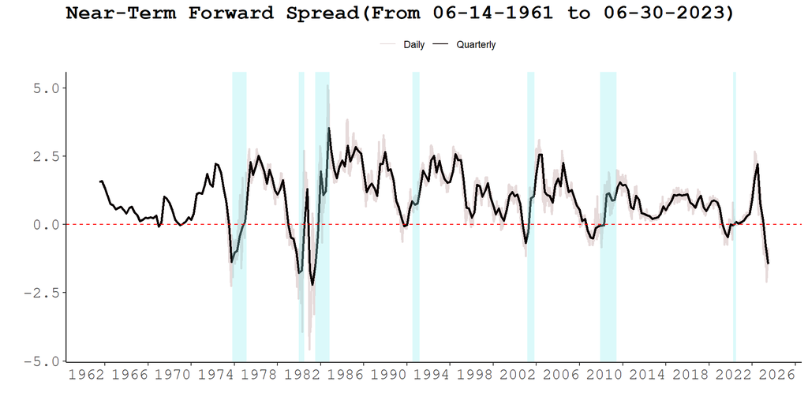

This plot shows from 1973 to now how many days NTFS was negative in each quarter.

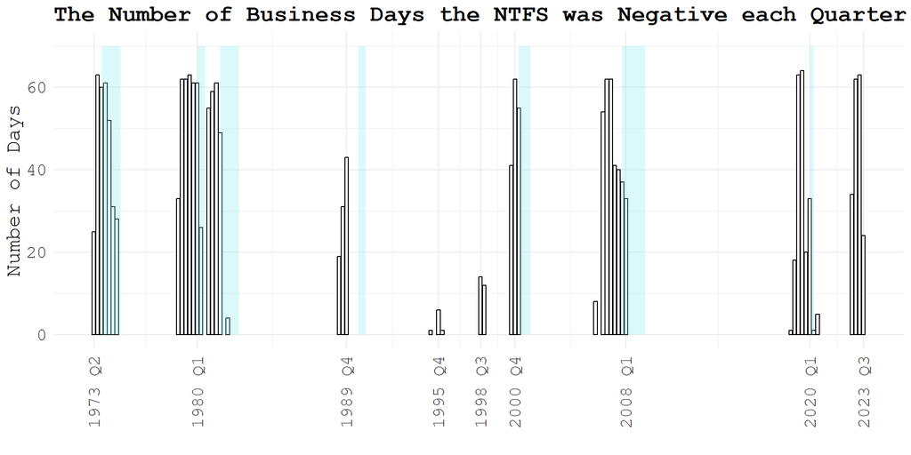

# **Model set up**

We used quarterly data to estimate the parameters. However, we only applied data for quarters that have finished. For example, in July 2023, we used data until the second quarter because the quarter had not finished yet, and keep the rest of the data (data from the beginning of the 3rd quarter to the end of the 3rd quarter) to calculate the probability of a recession for each week.

[Data](https://www.federalreserve.gov/data/nominal-yield-curve.htm)

The probability of the recession at each week can be calculated following steps:

1. Calculate the six quarter-ahead forward rate based on the methodology by Gurkaynak, Sack and Wright (2007),*The U.S. Treasury Yield Curve:1961 to the Present*:

   Six quarter-ahead forward rate:
   $$f_t(n,0)
   = \beta_0 + \beta_1exp(-n/\tau_1) + \beta_2(n/\tau_1)exp(-n/\tau_1) +
   \beta_3(n/\tau_2)exp(-n/\tau_2)$$
   where $f_t(n,0)$ is the forward rate and the coefficients that determine the forward rate in each period are $\beta_0,\beta_1,\beta_2,\beta_3,\tau_1,\tau_2$.The GSW formulation defines the instantaneous forward rate. For simplicity, I assume n=1.625 years.
2. Obtain the three-month Treasury bill rate
3. Calculate the near-term forward spread as the difference between the forward rate and the three month Treasury bill rate.
4. Use Prob/logit regression to estimate parameters
5. Plug in each week’s data from the current quarter to calculate the probability.

# **Model Output**

Here is the weekly output of the model from July 2022 to June 2023. The model forecasted a very low probability of a recession in the next four quarters in June 2022, and then it gradually increased as the Fed raised short-term interest rates.

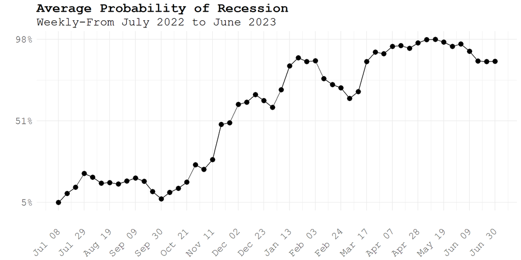